# Northern Essex Community College Department of Natural Sciences BIO 215 - General Ecology

# Instructor Contact Information

Instructor: Mark D. Clements, PhD  
Email: mclements@necc.mass.edu  
Office: E-373  
Virtual Office Hours: M (9-10; 2-3); T (2-3); TH (2-3); F (9-10; 2-3) or by appointment (I am flexible!)

About Me: My name is Dr. Mark Clements, but my students call me “Dr. C”. I have been teaching at the college for 10 years. I am an Ecologist who uses computers, data, and models to make sense of the world. It is my goal - as your mentor - to not only introduce you to Ecology but to also help you to understand and apply ecological ideas and scientific practices in the real world.

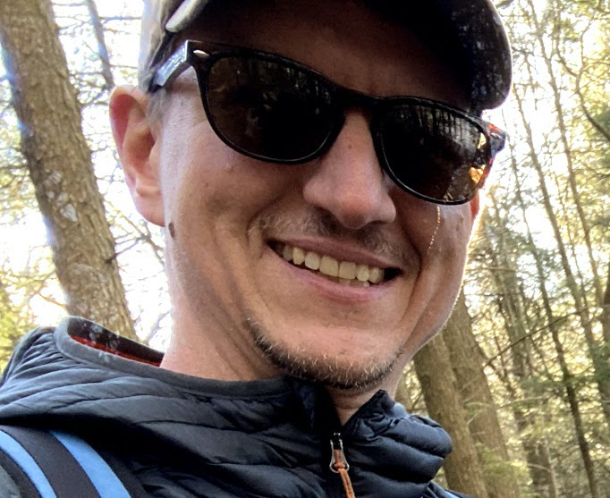

Dr. Mark Clements

# Course Information

Online Meeting Times: TBD  
Credits: 4  
Prerequisites: Reading proficiency and Writing proficiency or RWR090 Reading Writing and Reasoning Minimum Grade of: C or ENG101 or higher Minimum Grade of: C and Fndns of Algebra proficiency or MAT022 or higher Minimum Grade of: C

# General Course Description

This course aims to discuss the major ecological principles, focusing on organisms and the factors affecting their abundance and distribution, population structure and dynamics, community structure and processes, ecosystem processes and the biology of conservation. By the end of this course, you should be able discuss the complex linkages among the biotic and abiotic factors that structure natural communities, explain how these factors may be measured, and use models to predict impacts of change.

# General Course Objectives

## A2B Mass Transfer Ecology Course Outcomes (ECO):

ECO1 - Identify and explain ecological principles (at the individual, population, community, and ecosystem levels) and their roles in sustaining life on Earth.  
ECO2 - Critically evaluate and effectively use sources of ecological literature.  
ECO3 - Apply ecological tools and techniques to answer ecological questions.

## Essential Core Competencies (ECC):

ECC1 - Questioning and constructing hypotheses: generate a scientific question or construct one or more hypotheses about a real world event, observation, phenomenon, data, scenario, or model  
ECC2 - Planning investigations: design an experimental method or identify a set of observations that can be used to answer a scientific question or test a claim or hypothesis  
ECC3 - Developing and using models: construct a mathematical, graphical, computational, symbolic, or pictorial representation and use it to explain or predict an event, observation, or phenomenon  
ECC4 - Analyzing and interpreting data: analyze data, using quantitative thinking [^1], and interpret its meaning in the context of a question, claim, or hypothesis and data collected from an experiment or observation(s)  
ECC5 - Constructing explanations and arguments from evidence: construct or evaluate claims and explanations using evidence  
ECC6 - Evaluating information: find and assess the validity, credibility, and/or relevance of information and ideas

# Intensive Core Skills Objectives

## Written Communication Intensive (WCI):

WCI1 - Use writing to develop and explore relevant course content and or ideas.  
WCI2 - Compose essays geared to specific purposes and/or audiences according to the needs of a discipline.  
WCI3 - Create a thesis, find and use evidence to support it, and document material when necessary, as appropriate to the discipline.  
WCI4 - Organize and present content clearly, according to the conventions of the discipline.  
WCI5 - Apply instructor feedback for revising and editing formal essay assignments.

# Course Materials

A textbook is not required for this course. All learning activities are free and accessed using NECCs Blackboard learning management system. Everyone will use a web browser to participate; I recommend that you use [Google Chrome](https://www.google.com/chrome/) to avoid compatibility issues. We will use [Microsoft Office 365](https://www.necc.mass.edu/succeed/student-support-services/technology-help/student-email/office-365-help-login/) for assignments that require word processing, presentations, drawing, or spreadsheets because and it is free for all NECC students to download and use. Video content, created by the me or you, will use [Youtube](https://www.youtube.com/) or Kaltura (via Blackboard). I also encourage all of you to share any blogs, web site URLs, books, videos, etc., that you find that might be of value to this course and your classmates.

# Course Requirements

## Methods of instruction

The course is divided into several discrete, yet related modules. Modules have background readings, slide shows, and additional media (articles and videos) to introduce ideas and concepts. To help you remember, organize, and make sense of the basics we will engage in interactive discussions using these materials. Finally, there are activities that introduce scientific principles (experimental design, data collection, analysis, and evidence-based argumentation) and focus on the tools and techniques used in Ecology.

## Workload

The course is structured into weekly activities and requires a minimum of 5 hours of coursework per week. Coursework is completed asynchronously and I expect you to work at times that fit their schedule. I will be available as much as possible and will try to respond to any questions you may have within 48 hours.

### Reading + Discussion

The course uses reading combined with interactive discussions (i.e., Reading + Discussion) to assess understanding and retention of basic knowledge. Reading + Discussion participation and level of engagement with your classmates and me is assessed using the free Perusall app through Blackboard.

Perusall helps you reading faster, understand the material better, and get more out of your classes. To achieve this goal, you will be collaboratively annotating and discussing introductory materials with me and others in this class. The help you’ll get and provide your classmates (even if you don’t know anyone personally) will get you past confusions quickly and will make the process more fun. While you read, you’ll receive answers to your questions, help others resolve their questions (which also helps you learn), and advise the instructor on ideas that are difficult to understand. You can start a new annotation thread in Perusall by highlighting text, asking a question, or posting a comment; you can also add a reply or comment to an existing thread. Each thread is like a chat with one or more members of your class, and it happens in real time. Your goals in annotating each reading assignment are to stimulate discussion by posting good questions or comments and to help others by answering their questions.

Research shows that by annotating thoughtfully you’ll learn more, so here’s what “annotating thoughtfully” means: Effective annotations deeply engage points in the readings, stimulate discussion, offer informative questions or comments, and help others by addressing their questions or confusions. To help you connect with classmates, you can “mention” others in a comment or question to have them notified by email (they’ll also see a notification immediately if online), and you’ll also be notified when your classmates respond to your questions.

For each assignment I will evaluate the annotations you submit on time (see below). Based on the overall body of your annotations, you will receive a score for each assignment as follows

3 = demonstrates exceptionally thoughtful and thorough reading of the entire assignment  
2 = demonstrates thoughtful and thorough reading of the entire assignment  
1 = demonstrates superficial reading of the entire assignment OR thoughtful reading of only part of the assignment  
0 = demonstrates superficial reading of only part of the assignment

[Here are some examples of student annotations for you to review if you like.](https://perusall.com/downloads/scoring-examples.pdf)

**How many annotations do I need to enter?**

When we look at your annotations we want them to reflect the effort you put in your study of the text. It is unlikely that that effort will be reflected by just a few thoughtful annotations per assignment. On the other extreme, 30 per assignment is probably too many, unless a number of them are superficial or short comments or questions (which is fine, because it is OK to engage in chat with your peers). Somewhere in between these two extremes is about right and, thoughtful questions or comments that stimulate discussion or thoughtful and helpful answers to other students’ questions will earn you a higher score for the assignment. Note, also, that to lay the foundation for understanding the activities (see below), you must familiarize yourself with each assignment in its entirety. Failing to annotate the entire assignment will result in a lower score.

**What does “on time” mean?**

The Activities (see below) you complete in this course depend on you having done the reading in advance, so it is necessary to complete the reading and post your annotations by the deadline. I will allow annotations after the deadline with no penalty to your Reading + Discussion score but you will likely miss out on a lot of the more interesting and fun interactions with your peers. This is because most will have completed the Reading + Discussions and moved on to other activities in the course.

### Activities

Activities are submitted for review by the intructor and include: worksheets, spreadsheets, short writing assignments, video presentations, and/or drawings. Some assignments offer choices for final products (see Schedule). Activities can be resubmitted up to 3 times, after reviewing my feedback, to improve your performance. There is no penalty for submitting activities after the deadline and all activities are scored as 0 (resubmit) or 1 (satisfactory). The most important criteria for evaluating activities is student effort; so please try to complete the entire assignment and follow all instructions and provide me with the evidence that you have tried your best. If something requires more effort or correction, I will help you improve your work.

## Communication and interaction

We will communicate using Microsoft Teams chat (preferred), Perusall chat, or NECC email. Importantly, you should ask questions and use me as much as possible. I am here for you!

## Blackboard

Please make sure to login to Blackboard at least 3-4 times a week on different days. Announcements, class resources, and assignment submission will be handled through Blackboard. I will regularly send broadcast emails to the class through the Blackboard; this will send an email to your NECC student account, you can change which email account these messages are sent in your Blackboard settings.

## NECC Email

Please try to check your student email at least once per day. If you do not like the student email interface, it is easy to set up on your desktop client or mobile device. You can also forward your student mail to any other email account ([link to instructions](https://support.microsoft.com/en-us/office/turn-on-automatic-forwarding-in-outlook-on-the-web-7f2670a1-7fff-4475-8a3c-5822d63b0c8e?ui=en-us&rs=en-us&ad=us)).

Microsoft Teams chat or Perusal chat is the best way to contact me. If you send an email, you must include the following:  
- Your name  
- Your class (either course number or title)  
- A relevant subject

## Participation Policy

NECC online courses are asynchronous, meaning there are no set days and times to meet except for student requested appointments or office hours. Faculty may not use Zoom or other synchronous meeting tools to award or penalize students for attendance.

## Basis for Grading

Please make sure you check your grades for activities and discussion participation. Keeping track will ensure there are no discrepancies and surprises and notify you when I have provided feedback. Remember if course work is not submitted, then no feedback will be given, and you will not have the opportunity to improve your work. Deadlines for all assignments are flexible; it is most important to me that you complete the work to the best of your abilities even if it is submitted late.

| Category | Weighted Percentage |
| --- | --- |
| Reading + Discussion | 60% |
| Activities | 40% |

## Grading System

| Grade | QP Value | Numeric Range/Comment |
| --- | --- | --- |
| A | 4.00 | 93-100 |
| A- | 3.70 | 90-92 |
| B+ | 3.30 | 87-89 |
| B | 3.00 | 83-86 |
| B- | 2.70 | 80-82 |
| C+ | 2.30 | 77-79 |
| C | 2.00 | 73-76 |
| C- | 1.70 | 70-72 |
| D+ | 1.30 | 67-69 |
| D | 1.00 | 60-66 |
| F | 0.00 | 59 or less; failure; no credit earned |
| W | 0.00 | Withdrawal from course |
| NW | 0.00 | Non-participation withdrawal |

# Accessibility/Learning Disabilities

Northern Essex Community College is committed to providing equal access to students with documented disabilities. To ensure equal access to this class (and your program) please contact the Learning Accommodations Center (LA Center) or Deaf and Hard of Hearing Services (DHHS) to engage in a confidential discussion about accommodations for the classroom and clinical/practicum settings. Accommodations are not provided retroactively. You are encouraged to register with the LA Center at the start of their program.

*As your instructor, I feel I have a responsibility to do everything within reason to actively support a wide range of learning styles and abilities. As such, I have taken training and applied the principles of Universal Design for Learning (UDL) to this course. Feel free to discuss your progress in this course with me at any time. In addition, if you require any accommodations, submit your verified accommodations form to me during the first two weeks of the course.*

## Learning Accommodations Center:

Serving students with documented disabilities, such as learning disabilities, attention deficit disorders, autism spectrum disorders, brain injuries, chronic illness, low vision/blind, physical disabilities, psychiatric disabilities and seizure disorders.

## Deaf and Hard of Hearing Services (DHHS):

Serving students who are Deaf or Hard of Hearing. Accommodations are not provided retroactively. Students are encouraged to register with the LA Center or DHHS at the start of their program.

## Contact information during COVID-19:

The Learning Accommodations Center is scheduling remote appointments from 9:00 am to 5:00 pm. There are no face to face appointments being scheduled at this time. Communications can be flexible based on student’s needs and may consist of the following communication options: email, phone, Zoom, Skype, and text messaging. To get started, students may contact us as outlined below:

- Call the LA Center main number 978-556-3654 or email lacenter@necc.mass.edu
- DHHS call 978-241-7045 (VP/Voice) or email deafservices@necc.mass.edu
- To request an Interpreter or communication access email: interpret@necc.mass.edu

# Statement on Plagiarism and Academic Integrity

It is my goal to help you achieve your academic goals at NECC. Long term success is primarily determined by the skills and knowledge that you acquire from your coursework. It is most important that your academic achievements reflect your hard work and dedication to college. And when the latter is true, you will establish a reputation for honesty that will be more valuable than any grade that you receive in any class. Identifying ethical behaviors and establishing your personal integrity are the most important principles you will learn in college.

The following guidelines have been prepared so that you will understand what is expected of you in maintaining academic honesty:

1. All work in this class must be yours, unless I give you permission to collaborate with someone else. Please do not share your work with others – I encourage you to discuss work with others, but you must do your own work. 2. You should always give credit for material or ideas that you have obtained from a book, journal, magazine, or Web site. Please ask me for help if you are unsure how to properly acknowledge [your sources](http://necc.mass.libguides.com/noodletools). Failing to acknowledge that you have used another’s material or ideas is considered cheating and plagiarism.

> Definition of Plagiarism:
> - “The art of stealing words, ideas, etc. of another and using them as your own.” (Webster’s Dictionary)
> - “Take and use another author’s thoughts, writings as one’s own.” (The Concise Oxford Dictionary)
> - “The appropriation or imitation of the language, ideas, and thoughts of another author and the representation of them as one’s original work.”(The Random House Dictionary of the English Language)

Overt violations of these rules will result in any or all of the following:

- a grade of “0” for the assignment in question, or
- a grade of “F” in the course,
- or disciplinary action according to College rules

# Netiquette Guidelines

Please keep in mind the following guidelines when communicating with each other during this course:[^2]

- Always think before you write. Without the use of non-verbal communication as in conversation, your message can be misinterpreted. Please consider your tone before you hit submit.
- Keep it relevant. There are places to chat and post for fun. Please do not digress from the discussion in the assigned questions.
- Never use all caps. This is the equivalent of yelling in the online world. Only use capital letters when they are appropriate.
- Make sure that you are using appropriate grammar and structure.
- Treat people in the same way as you would treat them face-to-face. It is easy to hide behind the computer. In some cases, it empowers people to treat others in ways they would not in person. Please treat your fellow learners with dignity and respect.
- Respect the time of others. This class may require you to work in groups. Please respect the time of others in your group. You may be one that works best with the pressures of a deadline, but others may not. The key to a successful group is organization, communication and a willingness to do what it takes to get it done.

# Getting Help

I am here to help you with this course and to make this an enjoyable and worthwhile experience. If you would like assistance outside of class, please visit my virtual office hours or send me a message to arrange an appointment. Please do not wait until the last moment to ask for help. Remember, I am just an e-mail away. NECC also offers FREE tutoring and other services at:https://www.necc.mass.edu/succeed/academic-support-services/tutoring-center/

# Distance Education Course Interaction Plan (Form DE-2)

This form is to be completed by the faculty of record. Students enrolled in this distance education course shall receive a copy of this completed form.

Course Title: General Ecology  
Faculty: Mark D. Clements  
Email: mclements@necc.mass.edu

Asynchronous: This form of distance education is characterized by an emphasis on “learning on demand” or “as needed communication” between students and faculty from multiple locations at times convenient to participants.

This course may include, but not be restricted to, the following interactions:

|  | Yes | No |
| --- | --- | --- |
| 1. in person meetigs |  | * |
| 2. telephone interactions |  | * |
| 3. electronic interactions (email, internet …) | * |  |

If yes, dates, times, places are to be specified: Weekly and as requested by students.

Students are required to engage in the following interaction(s) for successful completion of this course: Perusall discussions with me and other students; online viewing of reading assignments, videos, and other digital media; online and desktop use of Office 365 products; online assignment submission (documents, video, and other digital media), online use of simulation software; occasional web-based conferencing via Microsoft Teams.

[^1]: Quantitative thinking involves the use of mathematics, statistics, computational algorithms, or other forms of quantitative analysis to interpret results within the context of a given event, observation, or phenomenon
[^2]: *The Core Rules of Netiquette are adapted from the book Netiquette by Virginia Shea*. Website: http://www.albion.com/netiquette/corerules.html